# r2mlm: R-squared for Multilevel Models

Mairead Shaw

## Load Data and Dependencies

```r
library(r2mlm) # this also loads lme4
library(lmerTest) # significance for coefficients
library(performance)
library(dplyr)
```

## Null Model

```r
null_model <- lmer(satisfaction ~ 1 + (1|schoolID), data = teachsat, REML = TRUE)
summary(null_model)
```

```
## Linear mixed model fit by REML. t-tests use Satterthwaite's method [
## lmerModLmerTest]
## Formula: satisfaction ~ 1 + (1 | schoolID)
##    Data: teachsat
##
## REML criterion at convergence: 30098.4
##
## Scaled residuals:
##     Min      1Q  Median      3Q     Max
## -3.8269 -0.6385  0.0012  0.6435  3.2874
##
## Random effects:
##  Groups   Name        Variance Std.Dev.
##  schoolID (Intercept) 0.699    0.836
##  Residual             1.516    1.231
## Number of obs: 9000, groups:  schoolID, 300
##
## Fixed effects:
##              Estimate Std. Error        df t value            Pr(>|t|)
## (Intercept)   5.99677    0.04998 299.00000     120 <0.0000000000000002 ***
## ---
## Signif. codes:  0 '***' 0.001 '**' 0.01 '*' 0.05 '.' 0.1 ' ' 1
```

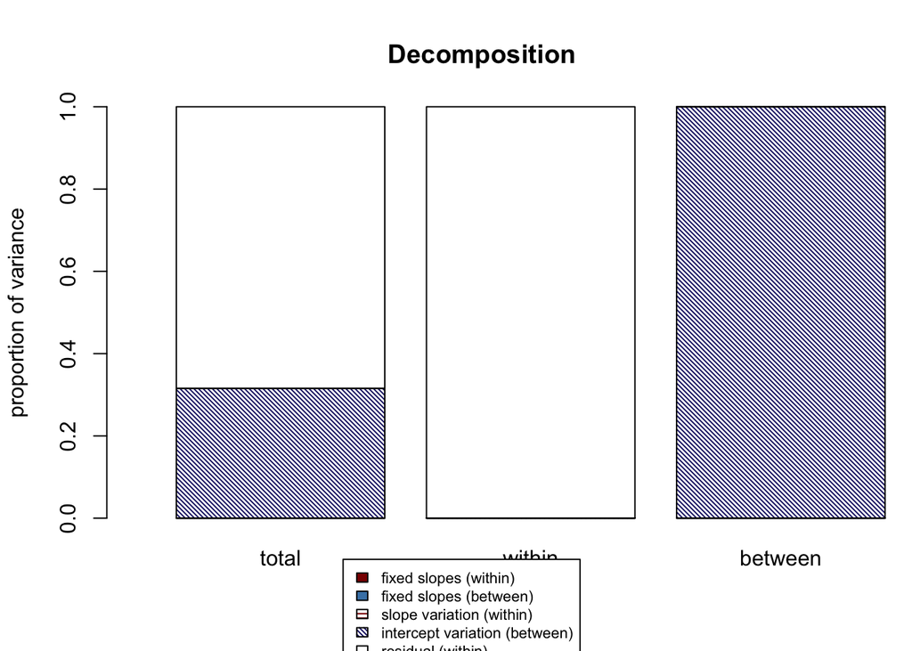

```
## $Decompositions
##                 total             within between
## fixed, within   0                 0      NA
## fixed, between  0                 NA     0
## slope variation 0                 0      NA
## mean variation  0.315546785367943 NA     1
## sigma2          0.684453214632058 1      NA
##
## $R2s
##     total             within between
## f1  0                 0      NA
## f2  0                 NA     0
## v   0                 0      NA
## m   0.315546785367943 NA     1
## f   0                 NA     NA
## fv  0                 0      NA
## fvm 0.315546785367943 NA     NA
```

```r
r2mlm(null_model)
```

Three sets of output: Decompositions, R2s, and Graph

- Decompositions give you the unique R-squareds
- R2s gives you the unique R-squareds and the combinations
- Graph visualizes Decompositions

My order of reading is usually: R2s, then look at the graph.

The only variance explained in job satisfaction is explained by group membership (random intercept). That’s the intraclass correlation! So 31.6% of variance in job satisfaction is attributed to cluster. For comparison, we can use the performance package to calculate the ICC:

```r
performance::icc(null_model)
```

```
## # Intraclass Correlation Coefficient
##
##      Adjusted ICC: 0.316
##   Conditional ICC: 0.316
```

They match, as expected!

## Full Model

1. Level-1: salary (centered within school)
2. Level-2: student-teacher ratio (same for all teachers within a school, differs across schools)

```r
model <- lmer(satisfaction ~ 1 + salary_c + s_t_ratio + (salary_c|schoolID),
              data = teachsat,
              REML = TRUE,
              control = lmerControl(optimizer = "bobyqa")) # optimizer change to help convergence (to make the example cleaner)
summary(model) # Instructive to look at our unstandardized results, too: coefficient values
```

```
## Linear mixed model fit by REML. t-tests use Satterthwaite's method [
## lmerModLmerTest]
## Formula: satisfaction ~ 1 + salary_c + s_t_ratio + (salary_c | schoolID)
##    Data: teachsat
## Control: lmerControl(optimizer = "bobyqa")
##
## REML criterion at convergence: 25878.2
##
## Scaled residuals:
##     Min      1Q  Median      3Q     Max
## -3.5436 -0.6507 -0.0042  0.6536  3.7282
##
## Random effects:
##  Groups   Name        Variance Std.Dev. Corr
##  schoolID (Intercept) 0.571138 0.75574
##           salary_c    0.002724 0.05219  -0.01
##  Residual             0.874365 0.93508
## Number of obs: 9000, groups:  schoolID, 300
##
## Fixed effects:
##               Estimate Std. Error         df t value             Pr(>|t|)
## (Intercept)   7.189783   0.144438 298.003026  49.778 < 0.0000000000000002 ***
## salary_c      0.074648   0.003231 300.385167  23.106 < 0.0000000000000002 ***
## s_t_ratio    -0.037282   0.004292 298.000395  -8.687 0.000000000000000251 ***
## ---
## Signif. codes:  0 '***' 0.001 '**' 0.01 '*' 0.05 '.' 0.1 ' ' 1
##
## Correlation of Fixed Effects:
##           (Intr) slry_c
## salary_c  -0.002
## s_t_ratio -0.951  0.000
```

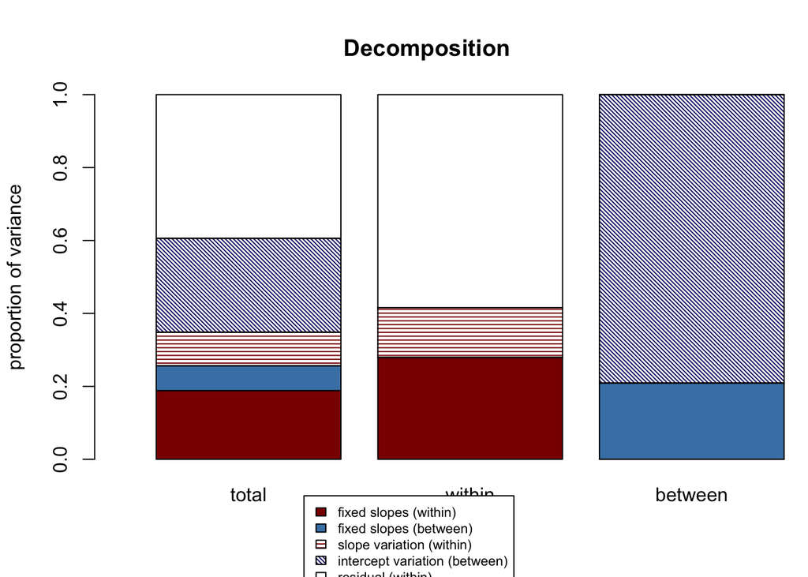

```
## $Decompositions
##                 total              within            between
## fixed, within   0.188362688254615  0.279254409150734 NA
## fixed, between  0.0680577989179737 NA                0.209099797402447
## slope variation 0.0920647772854669 0.136489318679158 NA
## mean variation  0.257422186062525  NA                0.790900202597553
## sigma2          0.394092549479419  0.584256272170108 NA
##
## $R2s
##     total              within            between
## f1  0.188362688254615  0.279254409150734 NA
## f2  0.0680577989179737 NA                0.209099797402447
## m   0.257422186062525  NA                0.790900202597553
## f   0.256420487172589  NA                NA
## fv  0.348485264458056  0.415743727829892 NA
## fvm 0.605907450520581  NA                NA
```

```r
r2mlm(model)
```

## Manual Entry

```r
r2mlm_manual(
  data = teachsat,
  within_covs = c("salary_c"),
  between_covs = c("s_t_ratio"),
  random_covs = c("salary_c"),
  gamma_w = c(0.074648),
  gamma_b = c(7.189783, -0.037282),
  Tau = as.matrix(bdiag(VarCorr(model))),
  sigma2 = getME(model, "sigma")^2,
  has_intercept = TRUE,
  clustermeancentered = TRUE
)
```

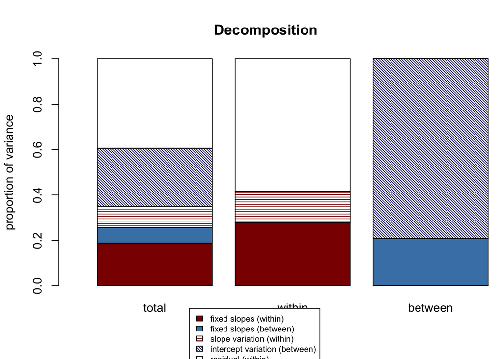

```
## $Decompositions
##                 total              within            between
## fixed, within   0.188363307468025  0.279255631555421 NA
## fixed, between  0.0680592513633171 NA                0.209103787514305
## slope variation 0.0920645207872735 0.136489087189454 NA
## mean variation  0.25742146886831   NA                0.790896212485695
## sigma2          0.394091451513075  0.584255281255124 NA
##
## $R2s
##     total              within            between
## f1  0.188363307468025  0.279255631555421 NA
## f2  0.0680592513633171 NA                0.209103787514305
## m   0.25742146886831   NA                0.790896212485695
## f   0.256422558831342  NA                NA
## fv  0.348487079618615  0.415744718744876 NA
## fvm 0.605908548486925  NA                NA
```

Compare to the automatic entry: they’re the same!

## Model Comparison

[figure not shown]

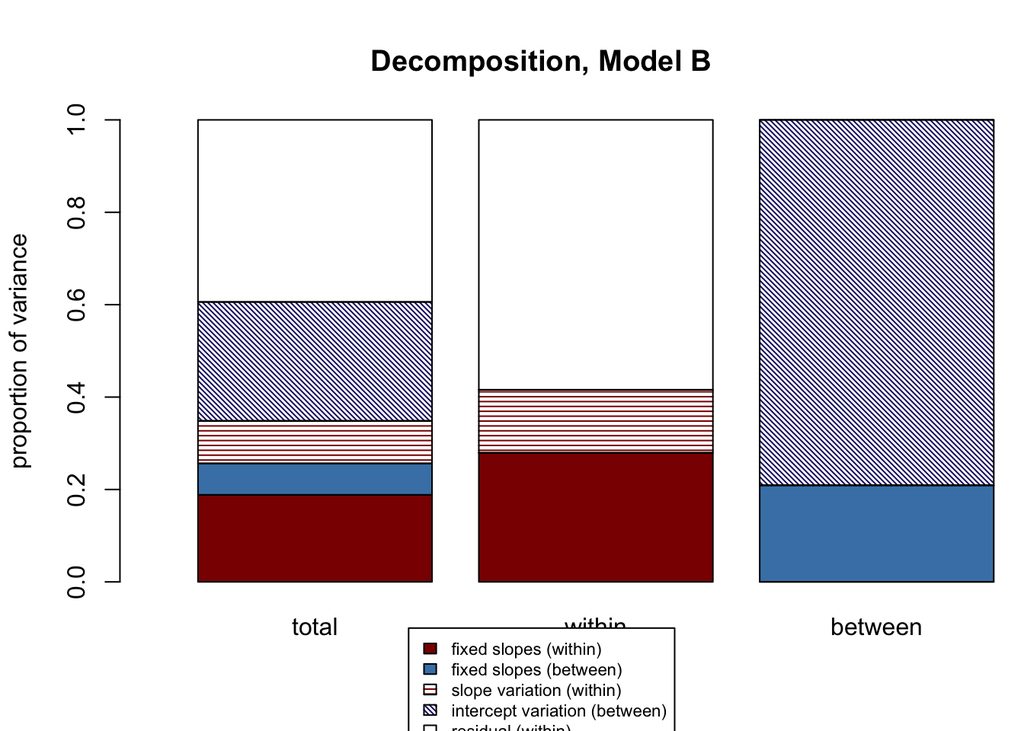

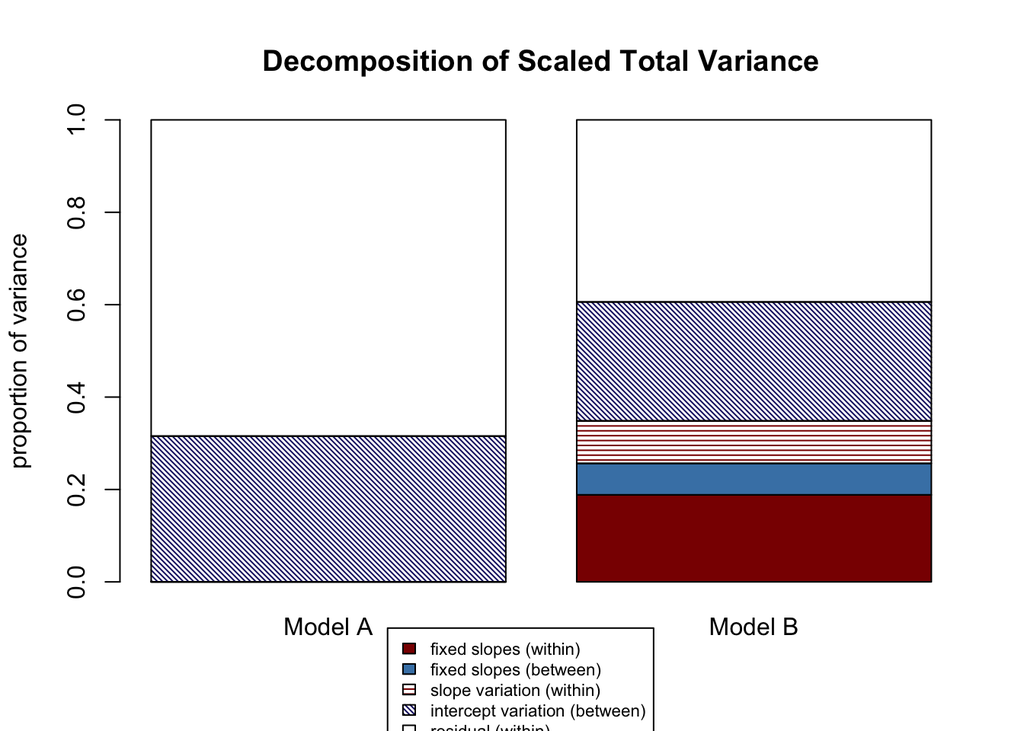

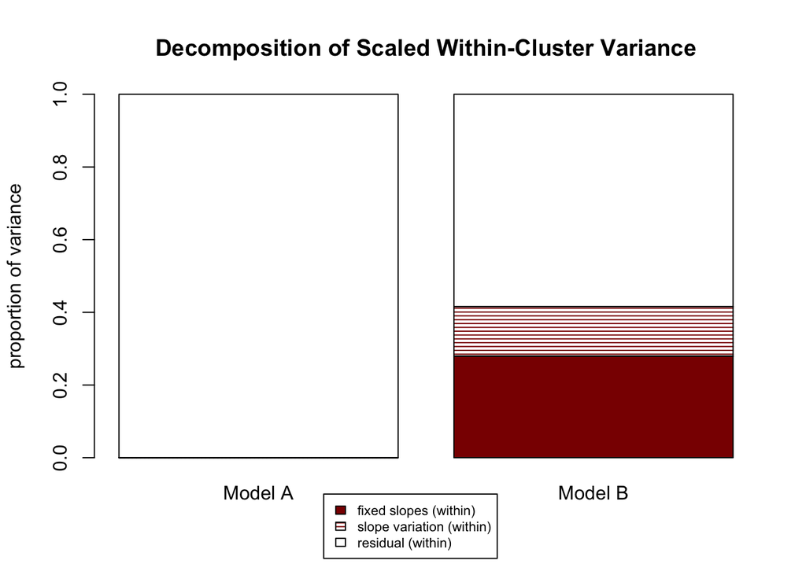

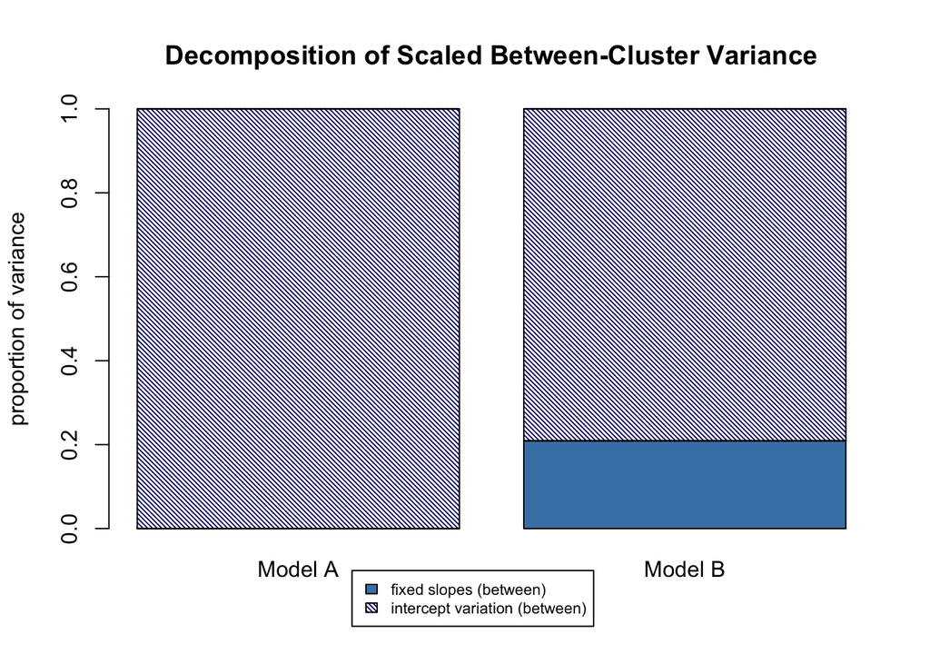

```
## $`Model A R2s`
##     total             within between
## f1  0                 0      NA
## f2  0                 NA     0
## v   0                 0      NA
## m   0.315546785367943 NA     1
## f   0                 NA     NA
## fv  0                 0      NA
## fvm 0.315546785367943 NA     NA
##
## $`Model B R2s`
##     total              within            between
## f1  0.188362688254615  0.279254409150734 NA
## f2  0.0680577989179737 NA                0.209099797402447
## m   0.257422186062525  NA                0.790900202597553
## f   0.256420487172589  NA                NA
## fv  0.348485264458056  0.415743727829892 NA
## fvm 0.605907450520581  NA                NA
##
## $`R2 differences, Model B - Model A`
##           total    within    between
## f1   0.18836269 0.2792544         NA
## f2   0.06805780        NA  0.2090998
## m   -0.05812460        NA -0.2090998
## f    0.25642049        NA         NA
## fv   0.34848526 0.4157437         NA
## fvm  0.29036067        NA         NA
```

```r
r2mlm_comp(null_model, model)
```

5 graph outputs: model A and B each overall, then comparisons of within, between, and total.

There is also manual entry for model comparison, but it’s verbose so we’re not going to look at it here.

## Non-CWC Model Options

```r
# You can see the centering, each school has a mean of zero
teachsat %>%
  group_by(schoolID) %>%
  summarize(
    mean(salary_c)
  )
```

```
## # A tibble: 300 x 2
##    schoolID `mean(salary_c)`
##       <int>            <dbl>
##  1        1         1.82e-16
##  2        2        -2.66e-16
##  3        3         2.66e-16
##  4        4        -7.46e-18
##  5        5        -4.62e-17
##  6        6         1.26e-16
##  7        7         2.00e-16
##  8        8        -5.94e-17
##  9        9         8.52e-17
## 10       10         7.40e-17
## # … with 290 more rows
```

```r
# Remove centering on salary by adding a constant to each value
teachsat <- teachsat %>%
  mutate(salary = salary_c + 1)

# You can see mean is no longer zero
teachsat %>%
  group_by(schoolID) %>%
  summarize(
    mean(salary)
  )
```

```
## # A tibble: 300 x 2
##    schoolID `mean(salary)`
##       <int>          <dbl>
##  1        1              1
##  2        2              1
##  3        3              1
##  4        4              1
##  5        5              1
##  6        6              1
##  7        7              1
##  8        8              1
##  9        9              1
## 10       10              1
## # … with 290 more rows
```

```r
# Model with this new salary
model_uncwc <- lmer(satisfaction ~ 1 + salary + s_t_ratio + (salary|schoolID),
              data = teachsat,
              REML = TRUE,
              control = lmerControl(optimizer = "bobyqa"))
summary(model_uncwc)
```

```
## Linear mixed model fit by REML. t-tests use Satterthwaite's method [
## lmerModLmerTest]
## Formula: satisfaction ~ 1 + salary + s_t_ratio + (salary | schoolID)
##    Data: teachsat
## Control: lmerControl(optimizer = "bobyqa")
##
## REML criterion at convergence: 25878.2
##
## Scaled residuals:
##     Min      1Q  Median      3Q     Max
## -3.5436 -0.6507 -0.0042  0.6536  3.7282
##
## Random effects:
##  Groups   Name        Variance Std.Dev. Corr
##  schoolID (Intercept) 0.574481 0.75795
##           salary      0.002724 0.05219  -0.08
##  Residual             0.874365 0.93508
## Number of obs: 9000, groups:  schoolID, 300
##
## Fixed effects:
##               Estimate Std. Error         df t value             Pr(>|t|)
## (Intercept)   7.115136   0.144482 298.325584  49.246 < 0.0000000000000002 ***
## salary        0.074648   0.003231 300.384844  23.106 < 0.0000000000000002 ***
## s_t_ratio    -0.037282   0.004292 298.000229  -8.687 0.000000000000000251 ***
## ---
## Signif. codes:  0 '***' 0.001 '**' 0.01 '*' 0.05 '.' 0.1 ' ' 1
##
## Correlation of Fixed Effects:
##           (Intr) salary
## salary    -0.025
## s_t_ratio -0.951  0.000
```

If you use the regular `r2mlm` function, you get just an overall breakdown. You can use `r2mlm_long` instead to get a full breakdown, though this option is only available as a manual function right now.

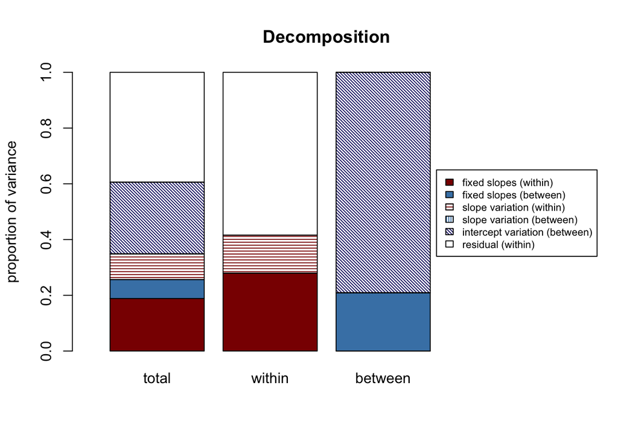

```
## $Decompositions
##                               total
## fixed slopes (within)         0.188363278106427
## fixed slopes (between)        0.0680592407544123
## slope variation (within)      0.0920645799175673
## slope variation (between)     0.0000000000000000000000000000000000354600596230147
## intercept variation (between) 0.257421525598485
## residual (within)             0.394091375623109
##                               within
## fixed slopes (within)         0.279255607120278
## fixed slopes (between)        NA
## slope variation (within)      0.136489184184975
## slope variation (between)     NA
## intercept variation (between) NA
## residual (within)             0.584255208694747
##                               between
## fixed slopes (within)         NA
## fixed slopes (between)        0.209103725289316
## slope variation (within)      NA
## slope variation (between)     0.000000000000000000000000000000000108946712951289
## intercept variation (between) 0.790896274710684
## residual (within)             NA
##
## $R2s
##     total                                               within
## f1  0.188363278106427                                   0.279255607120278
## f2  0.0680592407544123                                  NA
## v1  0.0920645799175673                                  0.136489184184975
## v2  0.0000000000000000000000000000000000354600596230147 NA
## m   0.257421525598485                                   NA
## f   0.256422518860839                                   NA
## fv  0.348487098778406                                   0.415744791305253
## fvm 0.605908624376891                                   NA
##     between
## f1  NA
## f2  0.209103725289316
## v1  NA
## v2  0.000000000000000000000000000000000108946712951289
## m   0.790896274710684
## f   NA
## fv  0.209103725289316
## fvm NA
```

```r
r2mlm_long_manual(
  data = teachsat,
  covs = c("salary", "s_t_ratio"),
  random_covs = c("salary"),
  clusterID = "schoolID",
  gammas = c(0.074648, -0.037282),
  Tau = as.matrix(Matrix::bdiag(VarCorr(model_uncwc))),
  sigma = getME(model_uncwc, "sigma")^2,
  bargraph = TRUE
)
```

Three outputs: Decompositions, R2s, Graph. This is similar to r2mlm(), but now there are two v terms. Recall that v is variance attributed to random slopes: v1 is slope variation within a cluster; v2 is slope variation between clusters. Why two v’s here? When a level-1 variable is centered within cluster, every cluster has a mean of 0 and there is no variance between clusters. All the variance is within clusters. When a level-1 variable is NOT centered within cluster, it varies both within and between clusters.

What does the `r2mlm_long` output look like with our centered model?

```r
summary(model)
```

```
## Linear mixed model fit by REML. t-tests use Satterthwaite's method [
## lmerModLmerTest]
## Formula: satisfaction ~ 1 + salary_c + s_t_ratio + (salary_c | schoolID)
##    Data: teachsat
## Control: lmerControl(optimizer = "bobyqa")
##
## REML criterion at convergence: 25878.2
##
## Scaled residuals:
##     Min      1Q  Median      3Q     Max
## -3.5436 -0.6507 -0.0042  0.6536  3.7282
##
## Random effects:
##  Groups   Name        Variance Std.Dev. Corr
##  schoolID (Intercept) 0.571138 0.75574
##           salary_c    0.002724 0.05219  -0.01
##  Residual             0.874365 0.93508
## Number of obs: 9000, groups:  schoolID, 300
##
## Fixed effects:
##               Estimate Std. Error         df t value             Pr(>|t|)
## (Intercept)   7.189783   0.144438 298.003026  49.778 < 0.0000000000000002 ***
## salary_c      0.074648   0.003231 300.385167  23.106 < 0.0000000000000002 ***
## s_t_ratio    -0.037282   0.004292 298.000395  -8.687 0.000000000000000251 ***
## ---
## Signif. codes:  0 '***' 0.001 '**' 0.01 '*' 0.05 '.' 0.1 ' ' 1
##
## Correlation of Fixed Effects:
##           (Intr) slry_c
## salary_c  -0.002
## s_t_ratio -0.951  0.000
```

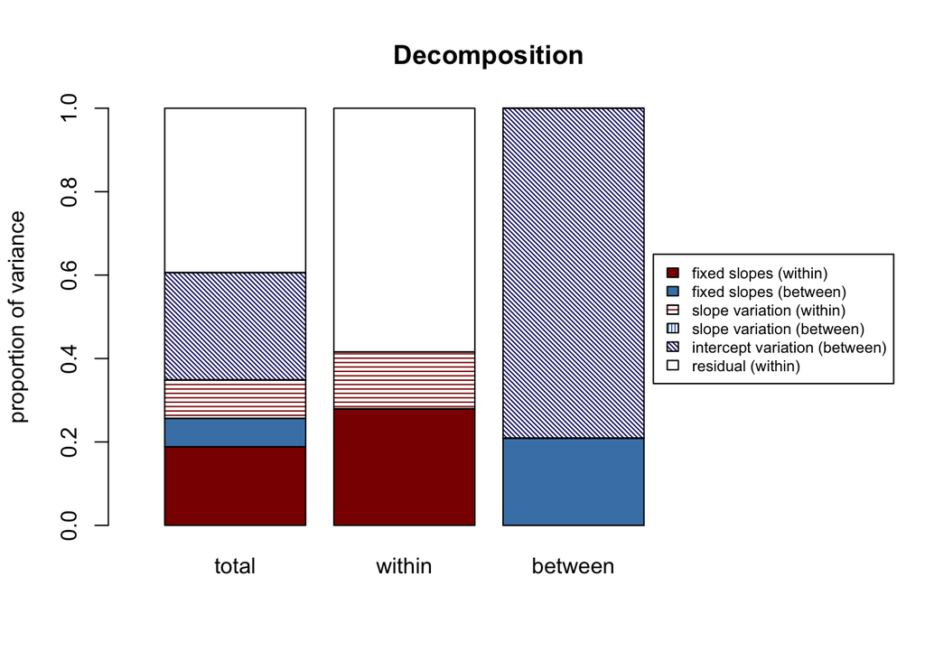

```
## $Decompositions
##                               total
## fixed slopes (within)         0.188363307468025
## fixed slopes (between)        0.0680592513633171
## slope variation (within)      0.0920645207872735
## slope variation (between)     0.0000000000000000000000000000000000307553254228165
## intercept variation (between) 0.25742146886831
## residual (within)             0.394091451513075
##                               within
## fixed slopes (within)         0.279255631555421
## fixed slopes (between)        NA
## slope variation (within)      0.136489087189454
## slope variation (between)     NA
## intercept variation (between) NA
## residual (within)             0.584255281255124
##                               between
## fixed slopes (within)         NA
## fixed slopes (between)        0.209103787514305
## slope variation (within)      NA
## slope variation (between)     0.0000000000000000000000000000000000944920037074072
## intercept variation (between) 0.790896212485695
## residual (within)             NA
##
## $R2s
##     total                                               within
## f1  0.188363307468025                                   0.279255631555421
## f2  0.0680592513633171                                  NA
## v1  0.0920645207872735                                  0.136489087189454
## v2  0.0000000000000000000000000000000000307553254228165 NA
## m   0.25742146886831                                    NA
## f   0.256422558831342                                   NA
## fv  0.348487079618615                                   0.415744718744876
## fvm 0.605908548486925                                   NA
##     between
## f1  NA
## f2  0.209103787514305
## v1  NA
## v2  0.0000000000000000000000000000000000944920037074072
## m   0.790896212485695
## f   NA
## fv  0.209103787514305
## fvm NA
```

```r
r2mlm_long_manual(
  data = teachsat,
  covs = c("salary_c", "s_t_ratio"),
  random_covs = c("salary_c"),
  clusterID = "schoolID",
  gammas = c(0.074648, -0.037282),
  Tau = as.matrix(Matrix::bdiag(VarCorr(model))),
  sigma = getME(model, "sigma")^2,
  bargraph = TRUE
)
```